# NHANES: HPV Infection by Sexual Behavior

Jennifer Spencer

9/8/2019

This file imports 7 cycles (14 years worth) of data from the National Health and Nutrition Examination Survey.

**The file proceeds as follows:**

**[1] We import the relevant files from raw NHANES files.**

**[2] We create a matched dataset containing all years and only the variables of interest.**

**[3] We define sexual behavior categories based on survey data**

**[4] We define HPV infection status based on laboratory data**

**[5] We compared HPV prevalence by sexual behavior data and save these estimates to put into a model**

### Import Data Files: NHANES 2003-2016

1. Demographic data file 2015-2016, 2013-2014, 2011-2012, 2009-2010, 2007-2008, 2005-2006, 2003-2004 We will use ID, Age, Gender, and 2-year exam-based survey weights

These variables had the same name in all years, so we create a program to extra these an loop over each year. (Program shown but the loops are hidden for the sake of space)

```r
# # # # Import & Select # # # #

      ## Demographic Variables  ##

f.demo_clean       <- function(data, year) {
  out_data         <- data   %>% select(      SEQN,  #ID
                                     "age"=RIDAGEYR, #Age
                                  "gender"=RIAGENDR, #Gender
                                      "wt"=WTMEC2YR, #weight
                                     "psu"=SDMVPSU,  #PSU
                                  "strata"=SDMVSTRA)  #Strata
  out_data$year    <- year

  return(out_data)
            }
```

Then we merge all years together.

```r
#Combine
demo_vars          <- rbind(demo_vars04, demo_vars06, demo_vars08, demo_vars10, demo_vars12, demo_vars14, demo_vars16)
demo_vars$ID       <- paste0(demo_vars$year, demo_vars$SEQN)
```

2. Laboratory data file 2015-2016, 2013-2014, 2011-2012, 2009-2010, 2007-2008, 2005-2006, 2003-2004: HPV DNA - Vaginal Swabs We will use the PCR data for all HPV types. For this dataset it is easier to keep all variables, but it some years there are extra variables (Hybrid Capture) that we want to remove.

```r
      ##Laboratory Variables ##

#2015-2016
laboratory_hpv_16          <- read.xport("./Inputs/NHANES/2016/HPVSWR_I.xpt")
  laboratory_hpv_16$year   <-2016


#2013-2014
laboratory_hpv_14          <- read.xport("./Inputs/NHANES/2014/HPVSWR_H.xpt")
    #just need to remove one variable
    laboratory_hpv_14      <- laboratory_hpv_14  %>% select(-LBXHP2C)
    laboratory_hpv_14$year <-2014

#2011-2012
laboratory_hpv_12          <- read.xport("./Inputs/NHANES/2012/HPVSWR_G.xpt")
    #just need to remove one variable
    laboratory_hpv_12      <- laboratory_hpv_12  %>% select(-LBXH2RL)
    laboratory_hpv_12$year <-2012

#2009-2010
laboratory_hpv_10          <- read.xport("./Inputs/NHANES/2010/HPVSWR_F.xpt")
    #just need to remove one variable
    laboratory_hpv_10      <- laboratory_hpv_10  %>% select(-LBXH2RL)
    laboratory_hpv_10$year <-2010


#2007-2008
laboratory_hpv_08          <- read.xport("./Inputs/NHANES/2008/HPVSWR_E.xpt")
   #just need to remove one variable
    laboratory_hpv_08      <- laboratory_hpv_08  %>% select(-LBXH3RL, -LBXH2RL)
    laboratory_hpv_08$year <-2008


#2005-2006
laboratory_hpv_06          <- read.xport("./Inputs/NHANES/2006/HPVSWR_D.xpt")
   #just need to remove one variable
    laboratory_hpv_06      <- laboratory_hpv_06  %>% select(-LBXH3RL, -LBXH2RL)
    laboratory_hpv_06$year <-2006

#2003-2004
laboratory_hpv_04          <- read.xport("./Inputs/NHANES/2004/L37SWR_C.xpt")
   #just need to remove one variable
    laboratory_hpv_04$year <-2004


#Combine
laboratory_hpv     <- rbind(laboratory_hpv_16, laboratory_hpv_14, laboratory_hpv_12,
                            laboratory_hpv_10, laboratory_hpv_08, laboratory_hpv_06, laboratory_hpv_04)

laboratory_hpv$ID  <- paste0(laboratory_hpv$year, laboratory_hpv$SEQN)
```

3. Questionnaire data file 2015-2016, 2013-2014, 2011-2012, 2009-2010, 2007-2008, 2005-2006, 2003-2004: Sexual History

We will use ID and sexual history variables. Some of these change name/wording slightly across years - the differences in this wording are relatively minor. However, in 2003-2004 they did not separately ask if participants had ever had sex with a man/woman, only the number. So in 2003-2004 there is no missingness in number but in later years they make it a two-part question and people who say “no” to the “ever” quesiton are missing in the “number of partners” questions.

So we correct this in the original data sets and save the variables we are interested in: number of male partners lifetime and in past year, number of female parters lifetime and past year, whether participant has ever had sex, and self-reported orientation.

```r
          ## Sexual Behavior ##
#Pull in sexual history variables

f.sex_clean        <- function(data, year) {

                if(year==2016) {

                  data$SXD101[data$SXQ700==2]     <- 0         # ever male asked as a separate q 2010-2016
                  data$SXQ130[data$SXQ709==2]     <- 0         # ever female asked as a separate q 2010-2016

    out_data         <- data   %>% select(           SEQN, #ID
                                      "ever_sex"  = SXD021,     #ever had sex
                                     "num_m_ever" = SXD101,     #   male partners lifetime
                                     "num_m_py"   = SXD450,     #   male partners past year
                                    "num_f_ever"  = SXQ130,     # female partners lifetime
                                      "num_f_py"  = SXQ490,     # female partners past year
                                    "orientation" = SXQ295 )     #orientation
  }
            else if (year>2008) {
                  data$SXD101[data$SXQ700==2]     <- 0         # ever male asked as a separate q 2010-2016
                  data$SXQ130[data$SXQ709==2]     <- 0         # ever female asked as a separate q 2010-2016

     out_data         <- data   %>% select(           SEQN, #ID
                                      "ever_sex"   = SXD021,     #ever had sex
                                      "num_m_ever" = SXD101,     #   male partners lifetime
                                     "num_m_py"    = SXD450,     #   male partners past year
                                    "num_f_ever"   = SXQ130,     # female partners lifetime
                                      "num_f_py"   = SXQ490,     # female partners past year
                                    "orientation"  = SXQ294)      #orientation
 }

             else if (year>2004) {


                  data$SXQ101[data$SXQ021==2]     <- 0         # single question for both M/F
                  data$SXQ130[data$SXQ021==2]     <- 0         # single question for both M/F

     out_data         <- data   %>% select(           SEQN, #ID
                                      "ever_sex"  = SXQ021,     #ever had sex
                                     "num_m_ever" = SXQ101,     #   male partners lifetime
                                     "num_m_py"   = SXQ450,     #   male partners past year
                                    "num_f_ever"  = SXQ130,     # female partners lifetime
                                      "num_f_py"  = SXQ490,     # female partners past year
                                    "orientation" = SXQ294)      #orientation
             }

                          else  {


                  data$SXQ100[data$SXQ020==2]     <- 0     #single question for both M/F
                  data$SXQ130[data$SXQ020==2]     <- 0     #single question for both M/F

     out_data         <- data   %>% select(           SEQN, #ID
                                      "ever_sex"  = SXQ020,     #ever had sex
                                     "num_m_ever" = SXQ100,     #   male partners lifetime
                                     "num_m_py"   = SXQ120,     #   male partners past year
                                    "num_f_ever"  = SXQ130,     # female partners lifetime
                                      "num_f_py"  = SXQ150,     # female partners past year
                                    "orientation" = SXQ294)      #orientation
  }


  out_data$year    <- year

  return(out_data)
}
```

Then we combine all three of these data sets together by patient ID. To account for survey weights properly, we can’t drop anyone but we do want to identify the subgroup that we are including. So we identify them and check the number included in each year.

```r
# # # # Combine by ID # # # #

#Match Sex Hx data by SEQN
full_nhanes        <- merge(demo_vars, sex_vars, by="ID", all = TRUE)

#Match Demo to Lab data by SEQN
full_nhanes        <- merge(full_nhanes, laboratory_hpv, by="ID", all = TRUE)

#Create a sample variable- I want women who have a PCR result
full_nhanes        <- full_nhanes %>% mutate(sample = ifelse(gender==2 & (LBDRPCR==1 |LBDRPCR==2) , 1, 0))

#If missing then replace with a 0
full_nhanes$sample <- ifelse(is.na(full_nhanes$sample), 0, full_nhanes$sample)

#cat_vars            <-c("gender", "ever_sex", "ever_m", "ever_f", "new_p_py", "sample")
#cat_nhanes          <-data.frame(apply(X=full_nhanes[,cat_vars], 2, as.factor))
#cont_nhanes         <-full_nhanes %>% select(SEQN, num_m_ever, num_f_ever, num_m_py, num_f_py, wt, psu, strata)

#Adjust weight for multiple years
full_nhanes$wt     <- (full_nhanes$wt /6)



#Look at participants by year
table(full_nhanes$sample, full_nhanes$year.x, useNA= "ifany")
```

```
##
##     2004 2006 2008 2010 2012 2014 2016
##   0 8564 8620 8366 8582 7989 8190 8113
##   1 1558 1728 1783 1955 1767 1985 1858
```

We then incorporate the survey weights from NHANES to reflect the US population

```r
# # # # Survey Weights  # # # #

#Create our survey design variable
nhanes_design      <- svydesign(id      = ~psu,
                                strata  = ~strata,
                                weights = ~wt,
                                nest    = TRUE,
                                data    = full_nhanes)

#tell it who our subsample is
hpv_sample        <- subset(nhanes_design, sample==1)
```

## Sexual History Data

Now we define women based on their sexual behavior data, favoring recent data such that:

| Category | Description |
| --- | --- |
| Not Sexually Active | No previous sexual partners |
| Heterosexual | Only opposite-sex partners OR majority of all partners or past year partner is opposite-sex with no more than 2 previous same-sex partners |
| Homosexual | Only same-sex partners OR majority of all partners or past year most recent partner is same-sex with no more than 2 previous opposite-sex partners |
| Bisexual | 1+ same-sex and 1+ opposite-sex partners in the previous year OR 3+ same-sex and 3+ opposite-sex lifetime partners OR 3+ same-sex partners lifetime and an opposite-sex partner in the previous year OR … |

```r
#First, clean up some of the variables that are conditional questions:
full_nhanes$num_m_ever[full_nhanes$ever_sex==2] <- 0
full_nhanes$num_f_ever[full_nhanes$ever_sex==2] <- 0
full_nhanes$num_m_py  [full_nhanes$ever_sex==2] <- 0
full_nhanes$num_f_py  [full_nhanes$ever_sex==2] <- 0

#If you said you didn't know, replace as NA
full_nhanes$num_m_ever[full_nhanes$num_m_ever==77777 |full_nhanes$num_m_ever==99999] <- NA
full_nhanes$num_f_ever[full_nhanes$num_f_ever==77777 |full_nhanes$num_f_ever==99999] <- NA



#Now define bisexual
#First by lifetime behavior
full_nhanes$behav[full_nhanes$num_m_ever>0  & full_nhanes$num_f_ever<3 ]    <- "heterosexual"
full_nhanes$behav[full_nhanes$num_f_ever>0  & full_nhanes$num_m_ever<3 ]    <- "homosexual"

#Then, replace favoring recency (if you haven't had 3 partners of one type we give preference to your more recent behavior)
full_nhanes$behav[full_nhanes$num_f_py>0]      <- "homosexual"
full_nhanes$behav[full_nhanes$num_m_py>0]      <- "heterosexual"

#Finally if you haven't had sex with anyone this year and have fewer than 3 of each,
      #we default to which group you've had more sex with, with ties going to lesbians
full_nhanes$behav[full_nhanes$num_f_py==0  & full_nhanes$num_m_py==0 &
                  full_nhanes$num_m_ever<3 & full_nhanes$num_m_ever<3 &
                    (full_nhanes$num_f_ever>=full_nhanes$num_m_ever)]       <- "homosexual"

#Then change identify as bisexual if you've had three of both or one of each in the previous year
full_nhanes$behav[(full_nhanes$num_f_ever>=3 & full_nhanes$num_m_ever>=3) |
                  (full_nhanes$num_f_py>=1   & full_nhanes$num_m_ever>=3) |
                  (full_nhanes$num_f_ever>=3 & full_nhanes$num_m_py>=1)  ]   <- "bisexual"

full_nhanes$behav[full_nhanes$num_f_py>=1     & full_nhanes$num_m_py>=1  ]   <- "bisexual"
#If you've never had sex you are in the none category
full_nhanes$behav[full_nhanes$ever_sex==2]                                   <- "none"

full_nhanes$behav[full_nhanes$sample==0]                                     <- NA
```

```r
  ((prop.table(table(full_nhanes$behav)))*100) %>%
  kable(digits=(c(0,2))) %>%
  kable_styling(bootstrap_options = c("condensed", full_width= F, position="center")) %>%
  column_spec(1, bold = T) %>%
     row_spec(3, color="#e7298a")  %>%
    row_spec(4, color="#7570b3")  %>%
    row_spec(2, color="#1b9e77")  %>%
    row_spec(1, color="#d95f02") %>%
  add_header_above(c("Raw Percent: Sexual Behavior (Primary Definition)"=2))
```

| Raw Percent: Sexual Behavior (Primary Definition) Var1 | Raw Percent: Sexual Behavior (Primary Definition) Freq |
| --- | --- |
| bisexual | 4.12 |
| heterosexual | 90.46 |
| homosexual | 0.81 |
| none | 4.62 |

```r
#
#  table(full_nhanes$behav, full_nhanes$year) %>%
#  kable(digits=(c(0,0))) %>%
#  kable_styling(bootstrap_options = c("condensed", full_width= F, position="center")) %>%
#  column_spec(1, bold = T) %>%
#    row_spec(3, color="#e7298a")  %>%
#    row_spec(4, color="#7570b3")  %>%
#    row_spec(2, color="#1b9e77")  %>%
#    row_spec(1, color="#d95f02")  %>%
#  add_header_above(c("Raw Frequency: Sexual Behavior by Year"=8))
#
```

We also use an alternative definition:

| Category | Description_Alternative |
| --- | --- |
| Not Sexually Active | No previous sexual partners |
| Heterosexual | Only opposite-sex partners |
| Homosexual | Only same-sex partners |
| Bisexual | Both M and F partners |

```r
#Now define bisexual
#First by lifetime behavior
full_nhanes$behav2[full_nhanes$num_m_ever>0  & full_nhanes$num_f_ever<1 ]    <- "heterosexual"
full_nhanes$behav2[full_nhanes$num_f_ever>0  & full_nhanes$num_m_ever<1 ]    <- "homosexual"

#Then, replace favoring recency (if you haven't had 3 partners of one type we give preference to your more recent behavior)
full_nhanes$behav2[full_nhanes$num_f_py>0]      <- "homosexual"
full_nhanes$behav2[full_nhanes$num_m_py>0]      <- "heterosexual"

#Finally if you haven't had sex with anyone this year and have fewer than 3 of each,
      #we default to which group you've had more sex with, with ties going to lesbians
full_nhanes$behav2[full_nhanes$num_f_py==0  & full_nhanes$num_m_py==0 &
                  full_nhanes$num_m_ever<1 & full_nhanes$num_m_ever<1 &
                    (full_nhanes$num_f_ever>=full_nhanes$num_m_ever)]        <- "homosexual"


#Then change identify as bisexual if you've had three of both or one of each in the previous year
full_nhanes$behav2[(full_nhanes$num_f_ever>=1 & full_nhanes$num_m_ever>=1)]  <- "bisexual"

full_nhanes$behav2[full_nhanes$num_f_py>=1     & full_nhanes$num_m_py>=1  ]  <- "bisexual"

#If you've never had sex you are in the none category
full_nhanes$behav2[full_nhanes$ever_sex==2]                      <- "none"


full_nhanes$behav2[full_nhanes$sample==0]                                    <- NA
```

We also use self-reported orientation. People were offered three choices or could select “Something Else”, “Don’t Know”, “Not Sure” or refuse completely. We restrict to only those who answered heterosexual, homosexual, or bisexual.

| Category | Description_Alternative |
| --- | --- |
| Not Sexually Active | –N/A– |
| Heterosexual | Identifies as straight/heterosexual |
| Homosexual | Identifies as lesbian/homosexual |
| Bisexual | Identifies as bisexual |

```r
#Pre2016
  full_nhanes$self_orient[full_nhanes$orientation==1 & full_nhanes$year <2016]  <-"heterosexual"
  full_nhanes$self_orient[full_nhanes$orientation==2 & full_nhanes$year <2016]  <-"homosexual"
  full_nhanes$self_orient[full_nhanes$orientation==3 & full_nhanes$year <2016]  <-"bisexual"

#2016
  full_nhanes$self_orient[full_nhanes$orientation==2 & full_nhanes$year==2016]  <-"heterosexual"
  full_nhanes$self_orient[full_nhanes$orientation==1 & full_nhanes$year==2016]  <-"homosexual"
  full_nhanes$self_orient[full_nhanes$orientation==3 & full_nhanes$year==2016]  <-"bisexual"
```

Number of partners is pretty right skewed, so we top-code it at 30 for the purpose of making our graphs/comparisons.

```r
#We also
full_nhanes$num_m_ever[full_nhanes$num_m_ever>30]  <- 30
full_nhanes$num_f_ever[full_nhanes$num_f_ever>30]  <- 30

full_nhanes$num_all <- full_nhanes$num_m_ever +  full_nhanes$num_f_ever
```

We now incorporate the complex survey design from NHANES to weight the raw numbers above to the full population.

| Weighted Percent: Sexual Behavior | Weighted Percent: Sexual Behavior mean | Weighted Percent: Sexual Behavior SE |
| --- | --- | --- |
| as.factor(behav)bisexual | 3.98 | 0.003 |
| as.factor(behav)heterosexual | 91.77 | 0.003 |
| as.factor(behav)homosexual | 0.67 | 0.001 |
| as.factor(behav)none | 3.58 | 0.002 |

| Weighted Percent: Sexual Behavior v. 2 | Weighted Percent: Sexual Behavior v. 2 mean | Weighted Percent: Sexual Behavior v. 2 SE |
| --- | --- | --- |
| as.factor(behav2)bisexual | 9.26 | 0.004 |
| as.factor(behav2)heterosexual | 86.89 | 0.004 |
| as.factor(behav2)homosexual | 0.27 | 0.000 |
| as.factor(behav2)none | 3.58 | 0.002 |

| Weighted Percent: Sexual Orientation | Weighted Percent: Sexual Orientation mean | Weighted Percent: Sexual Orientation SE |
| --- | --- | --- |
| as.factor(self_orient)bisexual | 4.12 | 0.002 |
| as.factor(self_orient)heterosexual | 94.54 | 0.003 |
| as.factor(self_orient)homosexual | 1.33 | 0.002 |

We can compare the concordance of our definition vs. orientation. Heterosexual and Homosexual match most of the time, but here is discorance with bisexual in both directions.

```r
#Compare self report to beahvior

   full_nhanes$concordant <- ifelse(is.na(full_nhanes$self_orient), NA,
                             ifelse(full_nhanes$self_orient==full_nhanes$behav, 1, 0))


   prop.table(table(full_nhanes$concordant, full_nhanes$behav), margin=2)
```

```
##
##       bisexual heterosexual homosexual       none
##   0 0.47215496   0.02163948 0.26315789 1.00000000
##   1 0.52784504   0.97836052 0.73684211 0.00000000
```

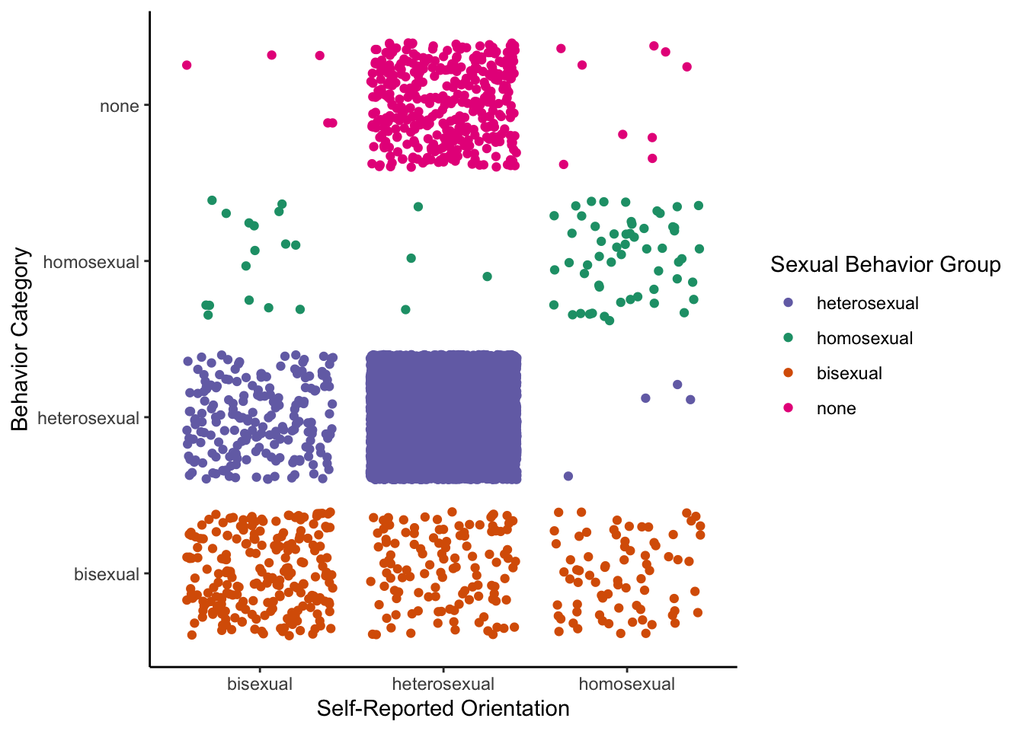

```r
  full_nhanes_compare <- full_nhanes %>%
                        drop_na(self_orient) %>%
                        drop_na(behav)


    ggplot() +
    geom_jitter(aes(y=full_nhanes_compare$behav, x=full_nhanes_compare$self_orient,
                    color=full_nhanes_compare$behav))   +
      scale_color_manual(name="Sexual Behavior Group",
                     breaks=c("heterosexual", "homosexual", "bisexual", "none"),
                     values=c("bisexual"="#d95f02", "homosexual"="#1b9e77", "none"="#e7298a", "heterosexual"="#7570b3"),
                     na.translate=FALSE) +
      ylab("Behavior Category") +
      xlab("Self-Reported Orientation") +
      theme_classic()
```

### Sexual Behavior Graphs

We can make graphs to show how each of our behavior categories (in our primary definition) split out by what gender their partners have been in the previous year and in their lifetime. By definition, we don’t see any “heterosexual” women who have had sex with a woman in the previous year or more than two women ever. The same goes for lesbian women having no sex with a man in the previous year and sex with not more than two men in their lifetime. Women who are not sexually active are, as we would expect, at 0 for both.

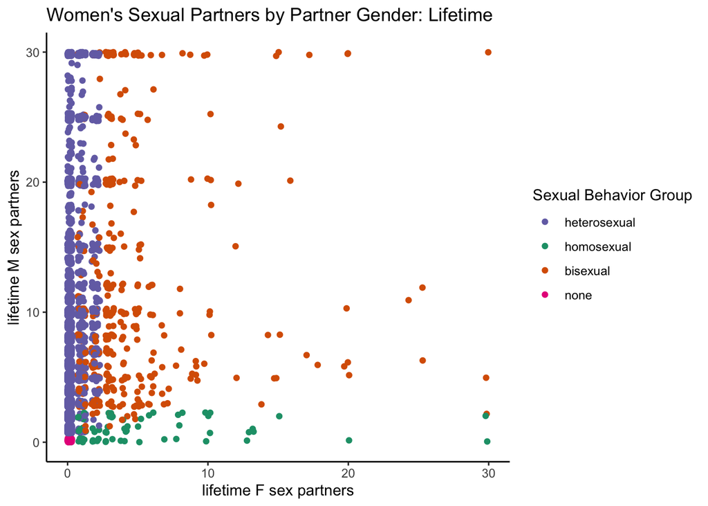

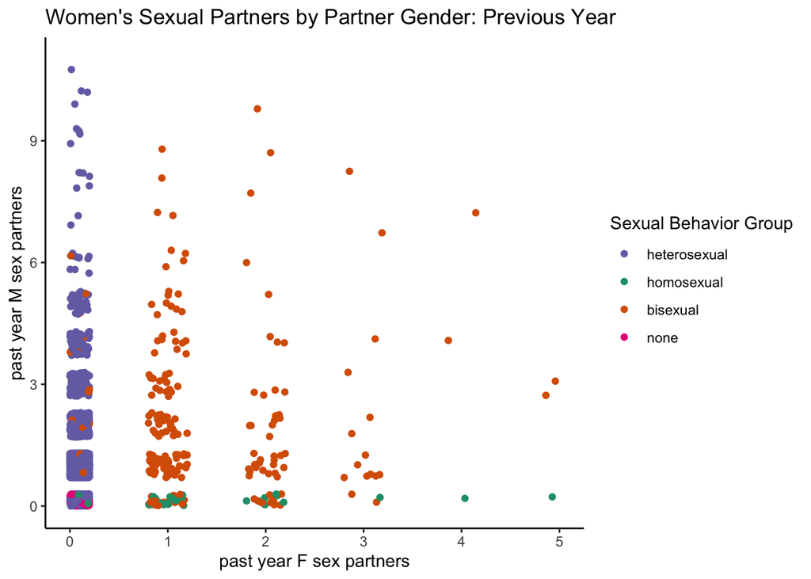

We can also look at how this splits out by self-reporting. We can see that identity doesn’t match behavior perfectly, so we see lesbians with higher #s of male partners and straight women with high #s of female partners.

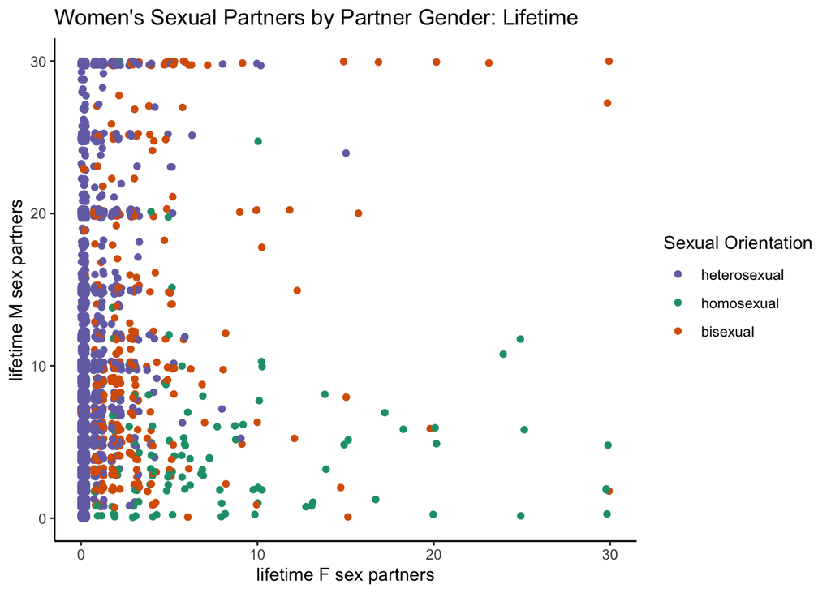

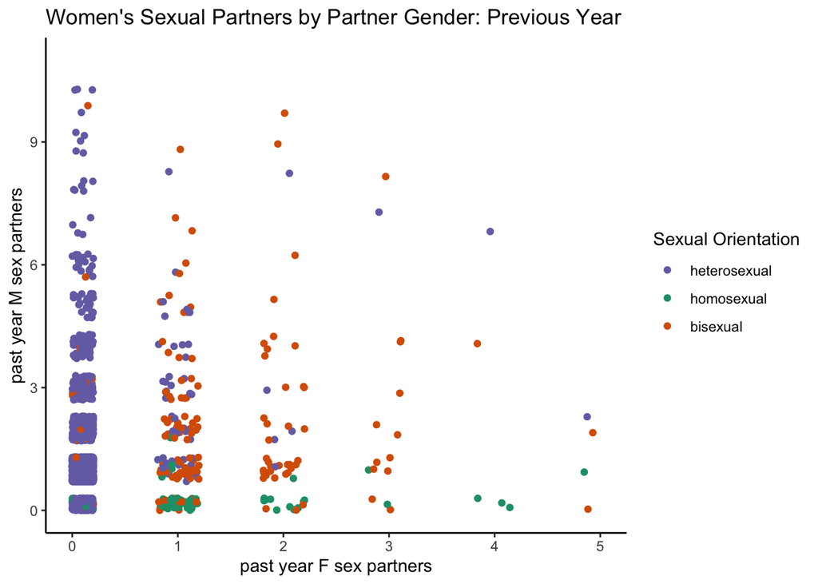

## Defining HPV

We identify HPV using the Vaginal swab data in NHANES categorized as

**-High risk** *HPV 16,18,31,33,35,39,45,51,52,56,58,59,66* or

**-Low risk** *HPV 6,11,26,40,42,53,54,55,61,62,64,67,68,69,70,71,72,73,81,82,83,84,IS39*

**-Any type** *(either high or low risk)*

```r
#Set everyone to zero
full_nhanes$any_hpv   <- 0
full_nhanes$low_hpv   <- 0
full_nhanes$high_hpv  <- 0

#Create funcitons for both low and high risk that replace you with "1" if you have that strain and otherwise return the value you already have.

#High Risk
f.high_risk           <- function(var) {
full_nhanes$any_hpv   <<- ifelse(var=="1", 1, full_nhanes$any_hpv)
full_nhanes$high_hpv  <<- ifelse(var=="1", 1, full_nhanes$high_hpv)
}

#Low Risk
f.low_risk            <- function(var) {
full_nhanes$any_hpv   <<- ifelse(var=="1", 1, full_nhanes$any_hpv)
full_nhanes$low_hpv   <<- ifelse(var=="1", 1, full_nhanes$low_hpv)
}


#High Risk Types
f.high_risk(full_nhanes$LBDR16)
f.high_risk(full_nhanes$LBDR18)
f.high_risk(full_nhanes$LBDR31)
f.high_risk(full_nhanes$LBDR33)
f.high_risk(full_nhanes$LBDR35)
f.high_risk(full_nhanes$LBDR39)
f.high_risk(full_nhanes$LBDR45)
f.high_risk(full_nhanes$LBDR51)
f.high_risk(full_nhanes$LBDR52)
f.high_risk(full_nhanes$LBDR56)
f.high_risk(full_nhanes$LBDR58)
f.high_risk(full_nhanes$LBDR59)
f.high_risk(full_nhanes$LBDR66)



#Low Risk Types
f.low_risk(full_nhanes$LBDR06)
f.low_risk(full_nhanes$LBDR11)
f.low_risk(full_nhanes$LBDR26)
f.low_risk(full_nhanes$LBDR40)
f.low_risk(full_nhanes$LBDR42)
f.low_risk(full_nhanes$LBDR53)
f.low_risk(full_nhanes$LBDR54)
f.low_risk(full_nhanes$LBDR55)
f.low_risk(full_nhanes$LBDR61)
f.low_risk(full_nhanes$LBDR62)
f.low_risk(full_nhanes$LBDR64)
f.low_risk(full_nhanes$LBDR67)
f.low_risk(full_nhanes$LBDR68)
f.low_risk(full_nhanes$LBDR69)
f.low_risk(full_nhanes$LBDR70)
f.low_risk(full_nhanes$LBDR71)
f.low_risk(full_nhanes$LBDR72)
f.low_risk(full_nhanes$LBDR73)
f.low_risk(full_nhanes$LBDR81)
f.low_risk(full_nhanes$LBDR82)
f.low_risk(full_nhanes$LBDR83)
f.low_risk(full_nhanes$LBDR84)
f.low_risk(full_nhanes$LBDR89)

table(full_nhanes$any_hpv, full_nhanes$year, useNA="ifany")
```

```
##
##         2004  2006  2008  2010  2012  2014  2016  <NA>
##   0      806   951   992  1061   991  1145  1109     0
##   1      781   800   806   909   781   850   763     0
##   <NA>   272   296   200   274   223   169   192 56687
```

### Analysis by Sexual Behavior Category

Now we use the survey-weighted data to compare prevalence of HPV by sexual behavior.

We compare by any, low risk, and high risk strains using first our primary definition of sexual behavior. We also calculate the mean number of sexual partners by sexual behavior category.

We then create both tables and graphs which we store to combine with other graphs later.

```r
results_any        <- svyby(~any_hpv,  by=~behav, hpv_sample, svymean, na.rm=TRUE, vartype =c("ci", "se"))
results_high       <- svyby(~high_hpv, by=~behav, hpv_sample, svymean, na.rm=TRUE, vartype =c("ci", "se"))
results_low        <- svyby(~low_hpv,  by=~behav, hpv_sample, svymean, na.rm=TRUE, vartype =c("ci", "se"))


results_partners   <- svyby(~num_all,  by=~behav, hpv_sample, svymean, na.rm=TRUE, vartype =c("ci", "se"))

results_any[2:5]   <- results_any[2:5]*100
#Add a formatted table

(r.table_behav      <- results_any[2:5] %>%
    kable(digits=(c(2,1,2,2))) %>%
     kable_styling(bootstrap_options = c("hover", "condensed", full_width= F, position="center")) %>%
      column_spec(1, bold = T) %>%
    row_spec(3, color="#e7298a")  %>%
    row_spec(4, color="#7570b3")  %>%
    row_spec(2, color="#1b9e77")  %>%
    row_spec(1, color="#d95f02") %>%
       add_header_above(c("Vaginal HPV Prevalence by Sexual Behavior Category: All Type"=5)))
```

| Vaginal HPV Prevalence by Sexual Behavior Category: All Type | Vaginal HPV Prevalence by Sexual Behavior Category: All Type any_hpv | Vaginal HPV Prevalence by Sexual Behavior Category: All Type se | Vaginal HPV Prevalence by Sexual Behavior Category: All Type ci_l | Vaginal HPV Prevalence by Sexual Behavior Category: All Type ci_u |
| --- | --- | --- | --- | --- |
| bisexual | 56.84 | 2.9 | 51.19 | 62.49 |
| heterosexual | 41.62 | 0.8 | 40.12 | 43.12 |
| homosexual | 29.11 | 6.1 | 17.13 | 41.09 |
| none | 15.67 | 2.1 | 11.63 | 19.71 |

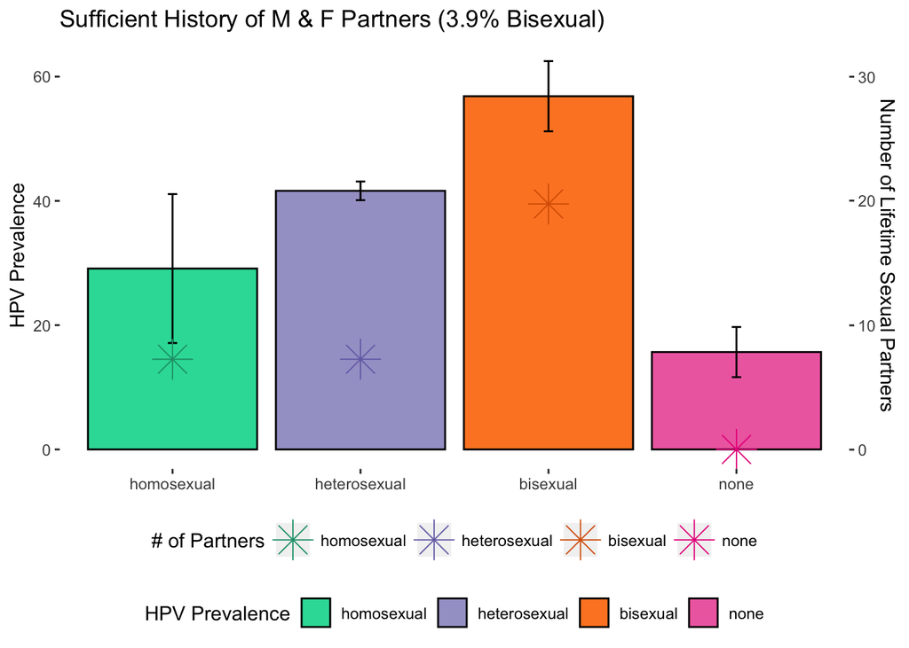

```r
#Reorder these for making graphs
results_any$behav  <-factor(results_any$behav, levels = c("homosexual", "heterosexual", "bisexual", "none"))
results_high$behav <-factor(results_high$behav, levels = c("homosexual", "heterosexual", "bisexual", "none"))
results_low$behav  <-factor(results_low$behav, levels = c("homosexual", "heterosexual", "bisexual", "none"))


#An all-type HPV graph
(behavior_all       <-
  ggplot() +
  geom_bar(aes(y=results_any$any_hpv, x=results_any$behav, fill=results_any$behav),
           stat="identity",  color="black") +
           ylab("HPV Prevalence") + xlab(NULL) +
   geom_errorbar(aes(x=results_any$behav, ymin=results_any$ci_l, ymax=results_any$ci_u), width=.05) +
   geom_point(aes(y=(results_partners$num_all*2), x=results_any$behav, color=results_any$behav), size=7, shape=8) +
          scale_y_continuous(sec.axis = sec_axis(~.*(1/2), name="Number of Lifetime Sexual Partners")) +
          scale_fill_manual(name="HPV Prevalence",
                     values=c("bisexual"="#fd862a", "homosexual"="#2bdba6", "none"="#ef6eb0", "heterosexual"="#a5a2ce")) +
          scale_color_manual(name="# of Partners",
                     values=c("bisexual"="#d95f02", "homosexual"="#1b9e77", "none"="#e7298a", "heterosexual"="#7570b3")) +
            theme(legend.position="bottom",
            legend.box = "vertical",
            panel.background = element_rect(fill = NA),) +
         ggtitle("Sufficient History of M & F Partners (3.9% Bisexual)"))
```

```r
 results_high[2:5] <- results_high[2:5]*100

 #And the same for just high risk
r.table_behav_high <-  results_high[2:5] %>%
     kable(digits=(c(2,2,2,2))) %>%
      kable_styling(bootstrap_options = c("hover", "condensed", full_width= F, position="center")) %>%
       column_spec(1, bold = T) %>%
     row_spec(3, color="#e7298a")  %>%
     row_spec(4, color="#7570b3")  %>%
     row_spec(2, color="#1b9e77")  %>%
     row_spec(1, color="#d95f02") %>%
    add_header_above(c("Vaginal HPV Prevalence by Sexual Behavior Category: High Risk"=5))



#A high-risk HPV graph
behavior_high      <-
  ggplot() +
  geom_bar(aes(y=results_high$high_hpv, x=results_high$behav, fill=results_high$behav),
           stat="identity",  color="black") +
           ylab("HPV Prevalence (High Risk)") + xlab(NULL) +
   geom_errorbar(aes(x=results_high$behav, ymin=results_high$ci_l, ymax=results_high$ci_u), width=.05) +
   geom_point(aes(y=(results_partners$num_all*2), x=results_any$behav, color=results_any$behav), size=7, shape=8) +
          scale_y_continuous(sec.axis = sec_axis(~.*(1/2), name="Number of Lifetime Sexual Partners")) +
           scale_fill_manual(name="Sexual Behavior Group: HPV Prevalence",
                     values=c("bisexual"="#fd862a", "homosexual"="#2bdba6", "none"="#ef6eb0", "heterosexual"="#a5a2ce")) +
          scale_color_manual(name="Sexual Behavior Group: # of Partners",
                     values=c("bisexual"="#d95f02", "homosexual"="#1b9e77", "none"="#e7298a", "heterosexual"="#7570b3")) +
         theme(legend.position="bottom",
         legend.box = "vertical",
         panel.background = element_rect(fill = NA),) +
         ggtitle("Sufficient History of M & F Partners (3.9% Bisexual)")


 results_low[2:5]  <- results_low[2:5]*100


  #And the same for just low risk
r.table_behav_low  <-  results_low[2:5] %>%
     kable(digits=(c(2,2,2,2))) %>%
      kable_styling(bootstrap_options = c("hover", "condensed", full_width= F, position="center")) %>%
       column_spec(1, bold = T) %>%
     row_spec(3, color="#e7298a")  %>%
     row_spec(4, color="#7570b3")  %>%
     row_spec(2, color="#1b9e77")  %>%
     row_spec(1, color="#d95f02") %>%
    add_header_above(c("Vaginal HPV Prevalence by Sexual Behavior Category: Low Risk"=5))

#A low-risk HPV graph
behavior_low       <-
  ggplot() +
  geom_bar(aes(y=results_low$low_hpv, x=results_low$behav, fill=results_low$behav),
           stat="identity",  color="black") +
           ylab("HPV Prevalence (Low Risk)") + xlab(NULL) +
   geom_errorbar(aes(x=results_low$behav, ymin=results_low$ci_l, ymax=results_low$ci_u), width=.05) +
   geom_point(aes(y=(results_partners$num_all*2), x=results_any$behav, color=results_any$behav), size=7, shape=8) +
          scale_y_continuous(sec.axis = sec_axis(~.*(1/2), name="Number of Lifetime Sexual Partners")) +
           scale_fill_manual(name="Sexual Behavior Group: HPV Prevalence",
                     values=c("bisexual"="#fd862a", "homosexual"="#2bdba6", "none"="#ef6eb0", "heterosexual"="#a5a2ce")) +
          scale_color_manual(name="Sexual Behavior Group: # of Partners",
                     values=c("bisexual"="#d95f02", "homosexual"="#1b9e77", "none"="#e7298a", "heterosexual"="#7570b3")) +
          theme(legend.position="bottom",
         legend.box = "vertical",
         panel.background = element_rect(fill = NA),) +
         ggtitle("Sufficient History of M & F Partners (3.9% Bisexual)")
```

We also do this for both alternative definitions (code not shown)

We can them combine our graphs to compare all of them

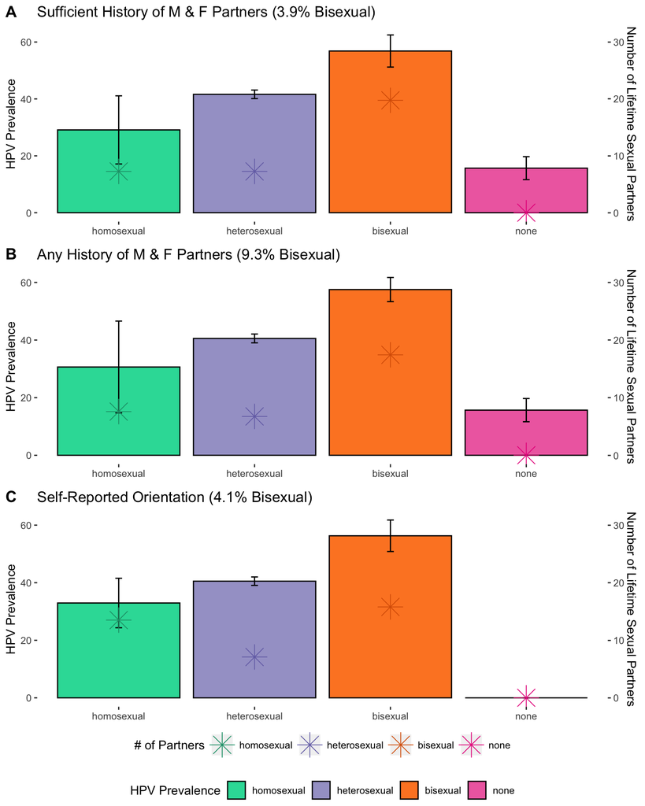

```r
(figure <- ggarrange(behavior_all, behavior2_all, orientation_all,
                    labels = c("A", "B", "C"),
                    ncol = 1,
                    nrow = 3,
                    common.legend=TRUE,
                    legend="bottom"))
```

```r
ggexport(figure, width=8, height=10, filename="./compare.pdf")
```

```
## file saved to ./compare.pdf
```

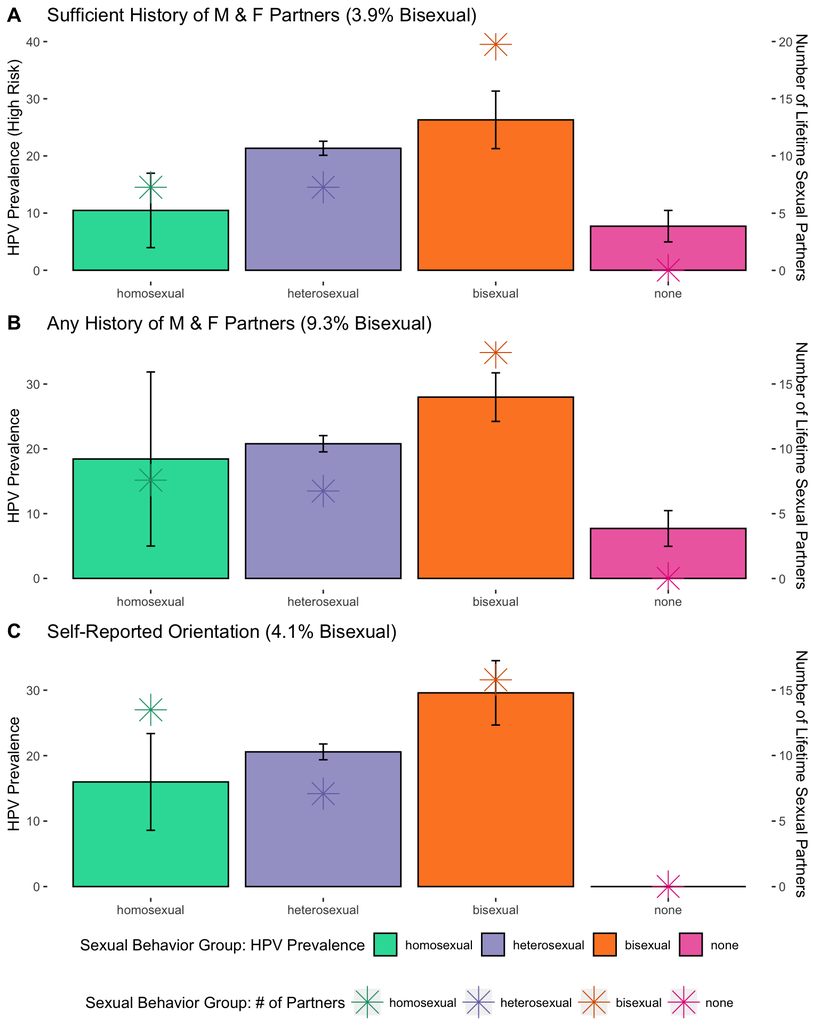

```r
(figure2 <- ggarrange(behavior_high, behavior2_high, orientation_high,
                    labels = c("A", "B", "C"),
                    ncol = 1,
                    nrow = 3,
                    common.legend=TRUE,
                    legend="bottom"))
```